# GEOG 5680 6680 14 R and Shiny

# Exercise

The zipfile *covid19.zip* contains a Shiny app to visualize the number of COVID-19 cases per country over time. Download this file and unzip it into your current working directory. This should create a new folder `covid19` which contains the following files.

- *ui.R*
- *server.R*
- A `data` folder, containing two files
  - *getData.R*
  - *covid_dat.csv*

Change your working directory to this new folder, load the *ui.R* and *server.R* files, and run the app to get the following screen:

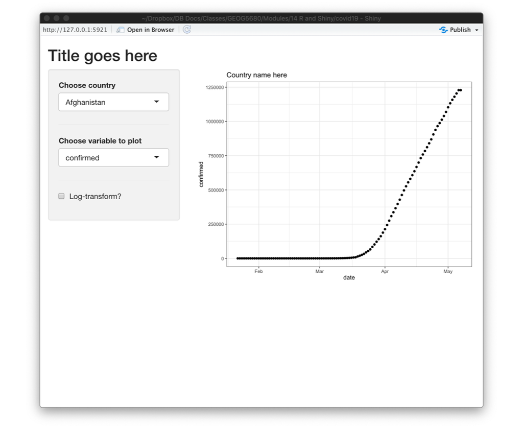

The app is designed to let you select a country and a variable to plot (e.g. number of deaths or cases), and it will then render this in the main window. While it should work out of the box, there are some problems with it. For the exercise, you will need to fix this, then submit your code as well as a Word document with a screenshot of the working corrected app, and the answer to the first two questions below:

- What are the parameters passed in the `input` list from the UI to the server?
- What are the parameters passed in the `output` list from the server to the UI?
- Improve the interface by adding a better title
- Add a more informative title to the figure, including the currently chosen country and variable
- Make the plot a line plot, not points
- Currently, the figure is always produced for the United States, irrespective of what is chosen from the country drop-down list. Fix the code to correct this
- The COVID19 data also includes information on the number of tests performed by country (`tests`), as well as the number of hospitalizations (`hosp`). Modify the scripts to include these variables in app (i.e. make them available in the drop-down variable menu, and allow them to be plotted). Pay attention to how the data is manipulated in the *server.R* script before the plot is made

Note: the *covid_dat.csv* data set in the `data` directory was downloaded on 5/7/2020. To update this, run the `getData.R` script in the `data` directory, which will update this csv file, by downloading current data from a set of different sources, including the Johns Hopkins CRC